# Le spectre de la reproductibilité avec R

*R à l’Usage des Sciences Sociales - Paris - 11 juin 2021*

## Recherche reproductible

## Reproductibilité, réplicabilité

Selon Claerbout, Donoho, Peng (… et Giraud) :

**Recherche reproductible** : Les auteurs fournissent les données et le code nécessaire pour rejouer les analyses et recréer les résultats numériques.

**Replication** : Une étude arrive aux même résultats scientifiques en collectant de nouvelles données (éventuellement avec des méthodes différentes) et en réalisant une nouvelle analyse.

**Attention**, d’autres auteurs et institutions inversent ces définitons, les utilisent de manière indifférenciée ou rajoute le concept de répétabilité.

Barba, L. A. (2018). Terminologies for reproducible research. arXiv preprint [arXiv:1802.03311](https://arxiv.org/abs/1802.03311).

## Le spectre de la reproductibilité

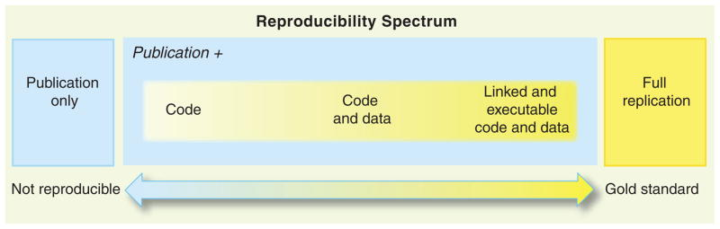

Peng R. D. (2011). Reproducible research in computational science. *Science (New York, N.Y.), 334*(6060), 1226–1227. https://doi.org/10.1126/science.1213847

## Panorama des solutions assurant la reproductibilité des analyses avec R

## La figure seule

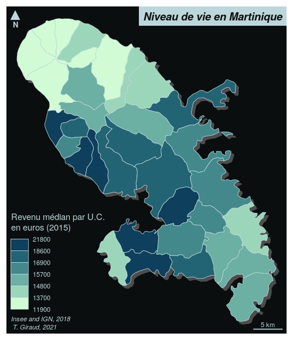

## La figure avec les données

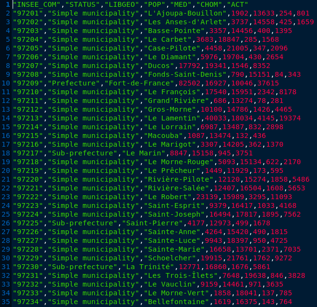

```
.
├── data
│   ├── martinique.gpkg
│   └── rev.csv
└── fig
    └── map.png
```

## La figure avec les données et les métadonnées

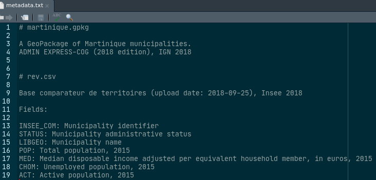

```
.
├── data
│   ├── martinique.gpkg
│   └── rev.csv
├── fig
│   └── map.png
└── metadata
    └── metadata.txt
```

## La figure, les données, les métadonnées et le script

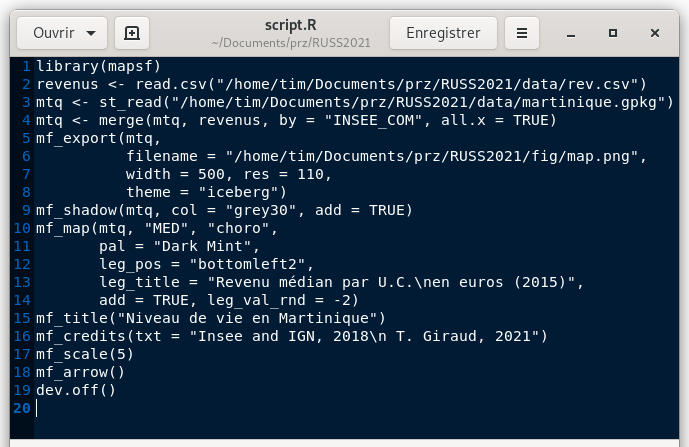

```
.
├── analyse
│   └── carte_revenus.R
├── data
│   ├── martinique.gpkg
│   └── rev.csv
├── fig
│   └── map.png
└── metadata
    └── medata.txt
```

## La figure, les données, les métadonnées et le script

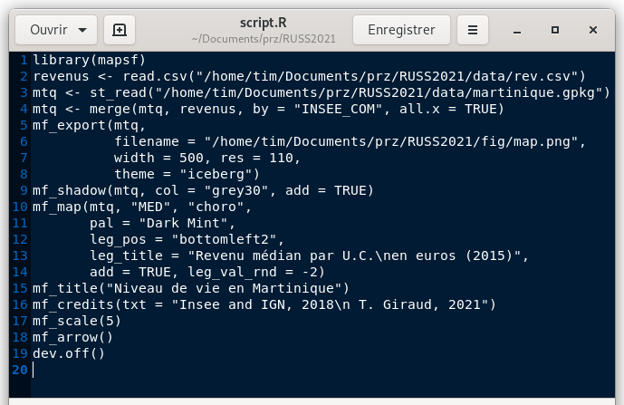

## Un projet RStudio

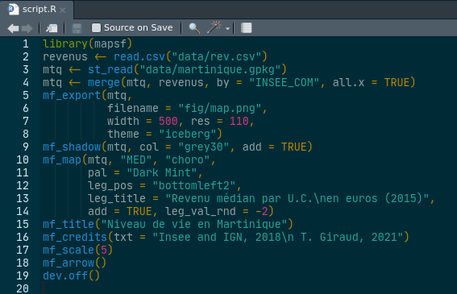

```
.
├── analyse
│   └── carte_revenus.R
├── data
│   ├── martinique.gpkg
│   └── rev.csv
├── fig
│   └── map.png
└── make_a_map.Rproj
```

## Un projet RStudio

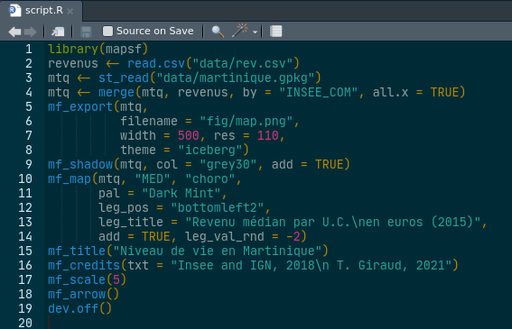

## Un projet RStudio + litterate programming + sessionInfo()

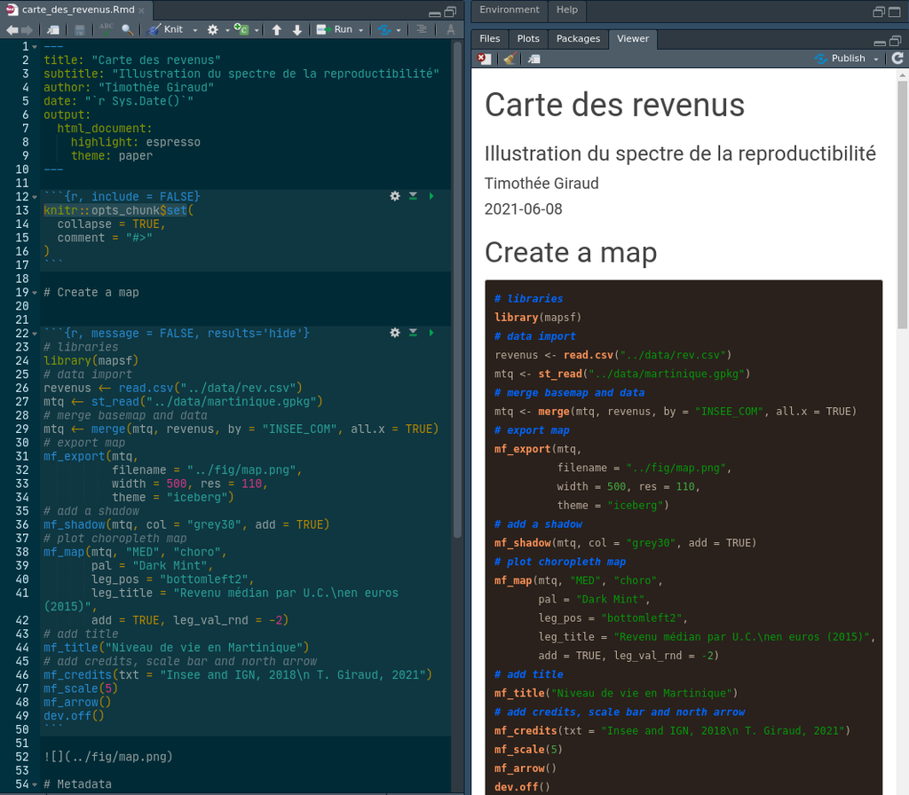

```
.
├── analyse
│   ├── carte_des_revenus.Rmd
│   └── carte_des_revenus.html
├── data
│   ├── martinique.gpkg
│   └── rev.csv
├── fig
│   └── map.png
├── make_a_map.Rproj
└── metadata
    └── metadata.txt
```

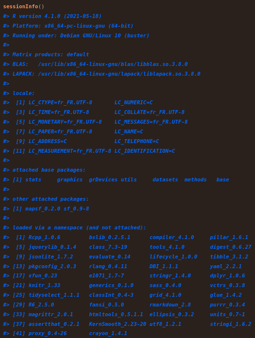

## Un gestionnaire de package

- [`renv`](https://rstudio.github.io/renv/) (succésseur de `packrat`)
- [`miniCRAN`](http://andrie.github.io/miniCRAN/) : créer un CRAN personnel
- [`checkpoint`](https://github.com/RevolutionAnalytics/checkpoint/)
- [`groundhog`](https://cran.r-project.org/web/packages/groundhog/index.html)

## `renv`

[figure not shown]

- Gerer les versions des packages utilisés dans un projet.
- Isoler, intelligemment, les packages par projet.

## `renv`

[figure not shown]

[Package renv : présentation et retour d’expérience, par Elise Maigné](https://r-toulouse.netlify.app/evenements/2021-05-28-diaporama-et-vid%C3%A9o-de-la-rencontre-de-mai-2021/)  
RUG Toulouse, mai 2021

## Make-like pipeline toolkit

[figure not shown]

`targets` (succésseur de `drake`)

- Pour les gros projets.
- Gestion des caches et parralélisation des tâches

## `targets`

[figure not shown]

[Reproducible Computation at Scale in R with {targets}, par Will Landau](https://www.meetup.com/R-Lille/events/277902715)  
RUG Lille, le 17 juin 2021

[Tutoriel officiel, une demi journée](https://github.com/wlandau/targets-tutorial)

## “Packager” son analyse

1 - Les packages fournissent une structure de dossiers standardisée pour organiser les fichiers  
2 - Les packages fournissent des fonctionnalités pour documenter les données et les fonctions  
3 - Les packages fournissent un cadre pour tester son code  
4 - se concentrer sur les points 1–3 permet de réutiliser et partager son code

[Put your Data Analysis in an R Package — Even if You Don’t Publish it, par Denis Gontcharov](https://towardsdatascience.com/put-your-data-analysis-in-an-r-package-even-if-you-dont-publish-it-64f2bb8fd791)

## Utiliser des containers

[Edzer Pebesma, Roger Bivand, Angela Li (helper). Spatial and Spatiotemporal Data Analysis in R. UseR! Workshop, Jul 9, 2019](https://github.com/edzer/UseR2019)

## Docker

[figure not shown]

```
docker pull riatelab/make_a_map:v1.0.0

docker run -d -e PASSWORD=xxx --rm -p 8787:8787 riatelab/make_a_map:v1.0.0
```

## Docker

[figure not shown]

- [An Introduction to Docker for R Users, par Colin Fay](https://colinfay.me/docker-r-reproducibility/)
- [An Introduction to Rocker: Docker Containers for R, par Carl Boettiger et Dirk Eddelbuettel](https://journal.r-project.org/archive/2017/RJ-2017-065/index.html)
- [Dockerizing your R analysis, par Phil Chapman](https://chapmandu2.github.io/post/2019/02/02/dockerizing-your-r-analysis/)

## Systèmes de gestion de version

git, GitHub, GitLab ???

- Git est un système de gestion de version distribué
  - tracker les changement dans les fichiers texte
  - gérer l’historique du code source
  - partager le code avec des dépots distantes
- GitHub et GitLab hébèrgent des dépots distants + des services pour gérer des projets (issue tracking, collaboration, hébergement web, CI/CD)
- GitLab a un modèle open-core. Possibilité d’héberger une instance.

## Git

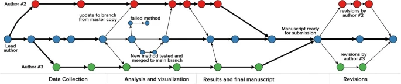

Ram, K. Git can facilitate greater reproducibility and increased transparency in science. *Source Code Biol Med 8*, 7 (2013). https://doi.org/10.1186/1751-0473-8-7

## Research Compendium

> *A research compendium accompanies, enhances, or is a scientific publication providing data, code, and documentation for reproducing a scientific workflow.*  
> https://research-compendium.science/
- https://rcarto.gitpages.huma-num.fr/centralite/

## Les données

Stocker / archiver ses données dans un dépôt respectant les principes FAIR :

[figure not shown]

[figure not shown]

## Et après?

[figure not shown]

Peer, L., Orr, L., & Coppock, A. (2021). Active Maintenance: A Proposal for the Long-Term Computational Reproducibility of Scientific Results. *PS: Political Science & Politics*, 1-5. doi:10.1017/S1049096521000366

## Quelques ressources

[CRAN Task View: Reproducible Research](https://cran.r-project.org/web/views/ReproducibleResearch.html)

[Recherche reproductible : principes méthodologiques pour une science transparente](https://www.fun-mooc.fr/fr/cours/recherche-reproductible-principes-methodologiques-pour-une-science-transparente/) MOOC de C. Pouzat, A. Legrand et K. Hinsen

[Vers une recherche reproductible](https://rr-france.github.io/bookrr/)

## Merci

rcarto.github.io/spectre-reproductibilite-r/  
[Code de la présentation](https://github.com/rCarto/spectre-reproductibilite-r)  
[@rgeomatic](http://twitter.com/rgeomatic)  
[rgeomatic.hypotheses.org](https://rgeomatic.hypotheses.org/)

```
R version 4.1.0 (2021-05-18)
Platform: x86_64-pc-linux-gnu (64-bit)
Running under: Debian GNU/Linux 10 (buster)

Matrix products: default
BLAS:   /usr/lib/x86_64-linux-gnu/blas/libblas.so.3.8.0
LAPACK: /usr/lib/x86_64-linux-gnu/lapack/liblapack.so.3.8.0

attached base packages:
[1] stats     graphics  grDevices utils     datasets  methods   base

other attached packages:
[1] knitr_1.33

loaded via a namespace (and not attached):
 [1] codetools_0.2-18  png_0.1-7         digest_0.6.27     R6_2.5.0          jsonlite_1.7.2
 [6] magrittr_2.0.1    evaluate_0.14     highr_0.9         rlang_0.4.11      stringi_1.6.2
[11] jquerylib_0.1.4   bslib_0.2.5.1     rmarkdown_2.8     tools_4.1.0       stringr_1.4.0
[16] xfun_0.23         yaml_2.2.1        compiler_4.1.0    htmltools_0.5.1.1 sass_0.4.0
```